# Group 2 Midterm Report

Brett Carey, Ryan Grayson, Nina Jannatifar

October 10th, 2022

# Introduction

## Background Information

For our midterm project, we chose to analyze a dataset found on Kaggle titled “Alcohol Effects on Study.” This was a large dataset comprising of two separate csv files with 33 different variables each. The data in these files were collected from two Portuguese high schools with the goal of predicting student performance in classes. The data was collected from students in math and Portuguese courses and the variables included the students grades, alcohol consumption patterns, and various other social, dempgraphic, and school-related factors. The data was analyzed in a paper by Cortez and Silva in 2008. A link to this paper is below.

[Kaggle](https://www.kaggle.com/datasets/08163f86754da93458b7dfb3e1c80258069edd817a00db655f3ccc3da37c87b5?resource=download&select=Maths.csv)

[Cortez and Silva, 2008](http://www3.dsi.uminho.pt/pcortez/student.pdf)

## List of Variables in this Dataset (information from Kaggle):

`school` (binary: ‘GP’ - Gabriel Pereira or ‘MS’ - Mousinho da Silveira)

`sex` (binary: ‘F’ - female or ‘M’ - male)

`age` (numeric: from 15 to 22)

`address` (binary: ‘U’ - urban or ‘R’ - rural)

`famsize` ( family size; binary: ‘LE3’ - less or equal to 3 or ‘GT3’ - greater than 3)

`Pstatus` (parent’s cohabitation status; binary: ‘T’ - living together or ‘A’ - apart)

`Medu` (mother’s education; numeric: 0 - none, 1 - primary education (4th grade), 2 - 5th to 9th grade, 3 - secondary education or 4 - higher education)

`Fedu` (father’s education; numeric: 0 - none, 1 - primary education (4th grade), 2 - 5th to 9th grade, 3 - secondary education or 4 - higher education)

`Mjob` (mother’s job; nominal: ‘teacher’, ‘health’ , ‘services’, ‘at_home’ or ‘other’)

`Fjob` (father’s job; nominal: ‘teacher’, ‘health’, ‘services’, ‘at_home’ or ‘other’)

`reason` (reason student choose this school; nominal: close to ‘home’, school ‘reputation’, ‘course’ preference or ‘other’)

`guardian` (nominal: ‘mother’, ‘father’ or ‘other’)

`traveltime` (home to school travel time; numeric: 1 - <15 min., 2 - 15 to 30 min., 3 - 30 min. to 1 hour, or 4 - >1 hour)

`studytime` (weekly study time; numeric: 1 - <2 hours, 2 - 2 to 5 hours, 3 - 5 to 10 hours, or 4 - >10 hours)

`failures` (number of past class failures; numeric: n if 1<=n<3, else 4)

`schoolsup` (extra educational support; binary: yes or no)

`famsup` (family educational support; binary: yes or no)

`paid` (extra paid classes within the course subject (Math or Portuguese); binary: yes or no)

`activities` (extra-curricular activities; binary: yes or no)

`nursery` (attended nursery school; binary: yes or no)

`higher` (wants to take higher education; binary: yes or no)

`internet` (Internet access at home; binary: yes or no)

`romantic` (in a romantic relationship; binary: yes or no)

`famrel` (quality of family relationships; numeric: from 1 - very bad to 5 - excellent)

`freetime` (free time after school; numeric: from 1 - very low to 5 - very high)

`goout` (going out with friendsl; numeric: from 1 - very low to 5 - very high)

`Dalc` (workday alcohol consumption; numeric: from 1 - very low to 5 - very high)

`Walc` (weekend alcohol consumption; numeric: from 1 - very low to 5 - very high)

`health` (current health status; numeric: from 1 - very bad to 5 - very good)

`absences` (number of school absences; numeric: from 0 to 93)

`G1` (first period grade; numeric: from 0 to 20)

`G2` (second period grade; numeric: from 0 to 20)

`G3` (final grade; numeric: from 0 to 20, output target)

# Data Analysis

## Question 1

### Is there a difference between the overall trend and consistency of grades affected by alcohol for math as opposed to portuguese?

**Hypothesis:** We hypothesize that the correlation between final Portuguese grades and alcohol consumption will be slightly stronger than the correlation between math grades and alcohol consumption (and we anticipate a negative correlation for both). Some studies have shown that genetics play a large role in math ability, whereas practice and effort often play a larger role in language ability. Assuming that greater alcohol consumption will typically lead to less time spent on academics, our hypothesis follows that the Portuguese grades would be more heavily correlated with higher alcohol consumption.

```r
# load packages
require(tidyverse)
require(gdata)
library(ggplot2)
library(dplyr)
# read in datasets
math <- read.csv("Maths.csv")
portuguese <- read.csv("Portuguese.csv")
```

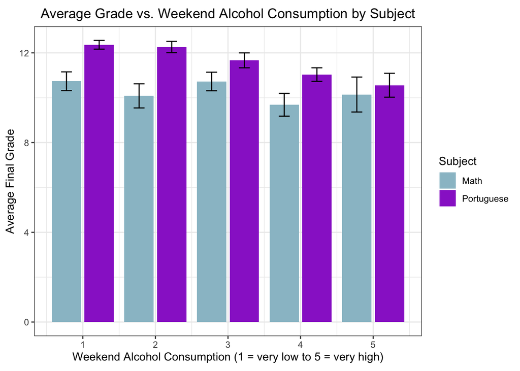

```r
# add mean and standard error for both datasets on the final grades, grouped by weekday alcohol consumption
math_walc_se <- math %>% group_by(Walc) %>% summarize(mean_g3=mean(G3), sd_g3=sd(G3),
                N_N=n(), se=sd_g3/sqrt(N_N), upper_limit=mean_g3+se, lower_limit=mean_g3-se)
port_walc_se <- portuguese %>% group_by(Walc) %>% summarize(mean_g3=mean(G3), sd_g3=sd(G3),
                N_N=n(), se=sd_g3/sqrt(N_N), upper_limit=mean_g3+se, lower_limit=mean_g3-se)
# join the data, keeping a new column for the dataset it came from.
alc_study <- combine(math_walc_se, port_walc_se)
# create a gglot with alcohol consumption on x, grade on y, and the fill representing math vs Portuguese
alc_plot <- ggplot(alc_study, aes(x=Walc, y=mean_g3, fill=source))
# add the bar chart with position dodge
alc_plot <- alc_plot + geom_bar(stat="identity", position="dodge2")
# add the error bars using the SE calculated above
alc_plot <- alc_plot + geom_errorbar(aes(ymin=lower_limit, ymax=upper_limit), width = .3, position=position_dodge(width = .9))
# add the theme, title, axis labels, and legend specs
alc_plot <- alc_plot + theme_bw() + theme(aspect.ratio = .8, plot.title = element_text(hjust = 0.5)) + labs(x = "Weekend Alcohol Consumption (1 = very low to 5 = very high)",
      y = "Average Final Grade", fill = "Subject", title="Average Grade vs. Weekend Alcohol Consumption by Subject") +
  scale_fill_manual(labels=c("Math", "Portuguese"), values = c("lightblue3", "darkorchid3"))
alc_plot
```

### Conclusion for Question 1

This bar chart helps us visualize the trends in grades for Math and Portuguese class for different levels of alcohol usage. Each bar contains the mean final grade for the specified subject and level of alcohol usage. We’ve also calculated the standard error for each, which is shown by the error bars on each data point. Here the grading scale used is arbitrary, since we are simply looking for trends. The axis is set at 0 to maintain consistency and to avoid magnifying trends for no good reason. The reason we chose a bar chart for this graph was because, while the alcohol consumption is a discrete scale, it is still a categorical variable as there are only 5 levels.

Looking at the Portuguese grades, a clear negative correlation is evident and with much lower standard error for each bar than for that of math, we can be more confident in this trend. For language subjects, effort put in is larger factor than for math because the coursework is often more memorization-based. For example, if there is a vocabulary quiz or an essay to write on a class reading, if one has not put in the time to study the vocab or do the reading, they simply cannot succeed. However for math, there is some level of intuition that could allow students to succeed without having put in the time to study or pay attention. Thus, the stronger downward trend for Portuguese grades makes some sense. It’s also helpful to note that with an alcohol consumption of 2, there is only a very slight dropoff in grades as opposed to the first level, and the error bars are very much overlapping. However, beyond that there is as steeper dropoff and little overlap in error bars from one level to the next, further reinforcing the trend we see.

In conclusion, this dataset suggests that Portuguese grades are more likely to be affected by alcohol consumption than math grades for Portuguese high school students.

## Question 2

### What is the relationship between weekend drinking and total study time for math students and does this differ significantly for males and females?

**Hypothesis:** We hypothesize that higher weekend alcohol consumption will correlate with lower average total study time, but we do not expect to see a significant difference in the magnitude of correlation between males and females. This assumes that a higher level of alcohol consumption will generally lead to students spending less time studying, causing the negative relationship we hypothesize. Women in general feel the effects of drinking more quickly than men due to biological differences. However, the variable measuring weekend alcohol consumption is a qualitative level and not a quantity, so we expect men and women who report the same level of consumption to experience essentially the same negative effect on their study habits.

```r
#preparing the data
MathData <- read.csv("Maths.csv")
PortData <- read.csv("Portuguese.csv")

#loading the packages
library(ggplot2)
library(tidyverse)
library(dplyr)
```

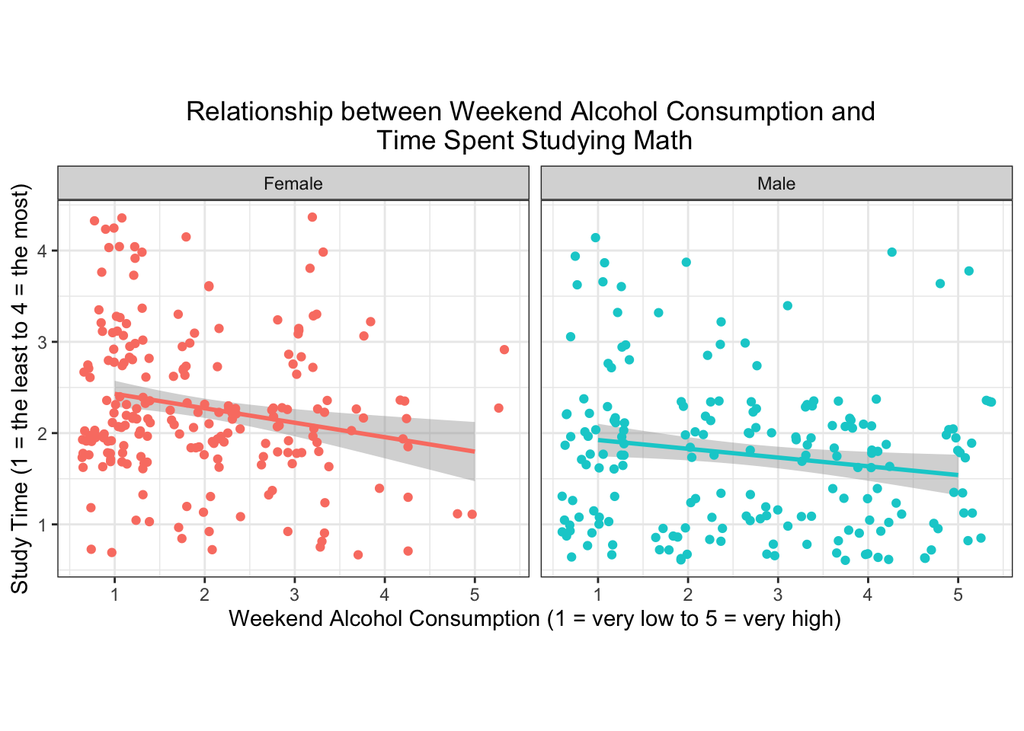

```r
sex.labs <- c("Female", "Male")
names(sex.labs)<- c("F", "M")
ggplot(MathData, aes(x = Walc, y = studytime, color = sex))+
       geom_smooth(method = "lm", se = TRUE)+
       geom_jitter()+
       scale_color_manual(breaks = c("F", "M"),
                       values=c("salmon", "darkturquoise"))+
       labs(x= "Weekend Alcohol Consumption (1 = very low to 5 = very high)", y = "Study Time (1 = the least to 4 = the most)", title = "Relationship between Weekend Alcohol Consumption and
Time Spent Studying Math")+
       theme_bw() +
       theme(plot.title = element_text(hjust = 0.5), aspect.ratio = .8, legend.position = "none")+
       facet_grid( . ~ sex, labeller = labeller(sex = sex.labs))
```

### Conclusion for Question 2

These side-by-side scatter charts with regression lines help us understand the relationship between weekend alcohol consumption and time spent studying for math as separated by sex. Both the study time and weekend alcohol variables are discrete, so we used geom_jitter to unstack the crowded points. The gray shaded areas around the regression lines visualize the 95% confidence interval. Since this question explicitly concerned the relationship between alcohol and study habits, we believed a scatter plot with a regression line would be best tailored to answering it.

Of first note, both the female and male regression lines show that there is a negative relationship between alcohol consumption and time spent studying for math in this data as we predicted in our hypothesis. However, this relationship does not appear to be a particularly strong one, as shown by the gradual slope of the regression line. Furthermore, the confidence interval bands indicate that the relationship may be even less strong than the lines imply. A further review of the individual points reveals that there are male and female students who drink heavily and yet still spend plenty of their time studying. As we said above, heavy alcohol usage evidently could affect people differently. These caveats necessarily temper the way in which we view the overall negative observed relationship.

Second, while the graphs seem to indicate that female students at any given level of alcohol use tend to study more for math than male students, the slope of the lines, especially in light of the confidence bands, are not significantly different. This is in line with our prediction that the effects of alcohol use would be about the same across sexes. One caution is the visible lack of female students who drink at the 4 and 5 levels in comparison to male students, since it is possible that heavy drinking might acutely affect females due to biology. This is reflected in the particularly wide confidence band at the far right of the female student regression line. A more robust conclusion of insignificant difference might be drawn if the study included more female heavy drinkers.

In conclusion, the graphs reveal a weak negative relationship between alcohol consumption and time spent studying for math for both female and male students whose magnitude does not significantly differ by sex.